# Drainage Density

Alice Carter

2022-10-01

Drainage density is the total stream length per unit area in a watershed:

$$D = \frac{\sum{L}}{A}$$

This metric may be useful to represent the connectivity of a stream to the terrestrial ecosystem carbon cycle. Higher drainage density would suggest that there is more exposed surface waters per unit area of terrestrial ecosystem. If we only include *connected stream length* to do this calculation, (ie we exclude sections of stream that are upstream of flow ubstructions), then the drainage density would decrease in a watershed where there are large areas disconnected from the stream by flow impoundments. Below, we explore how this metric behaves with other watershed properties.

Horton developed a scaling relationship between stream length ($L$) and watershed Area ($A$)

$$L = 1.27 A^{0.6}$$
This relationship implies that in a watershed that is 1 km squared, we would expect 1.27 kms of stream channel.

To understand how drainage density scales with watershed area we can calculate $D$ in terms of $A$:

$$D = \frac{\sum{L}}{A} = \frac{1.27
A^{0.6}}{A} = 1.27 A^{-0.4}$$

So we see that drainage density decreases proportional to the log of watershed area.

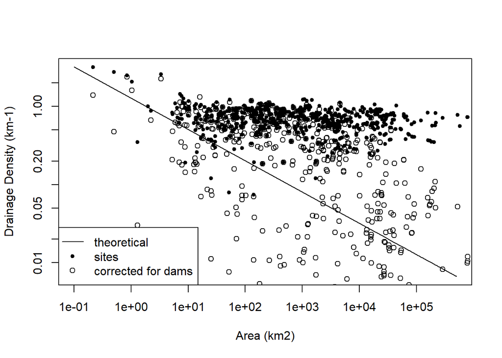

This makes sense as we expect stream reaches farther down in a watershed to be less connected to the terrestrial system and more controlled by internal dynamics.

Drainage density also covaries with flow characteristics. Higher drainage densities predict lower average baseflow ($Q_b$) and higher storm flow ($Q_f$)

$$Q_b \propto D^{-2}$$
$$Q_f \propto D^{2}$$

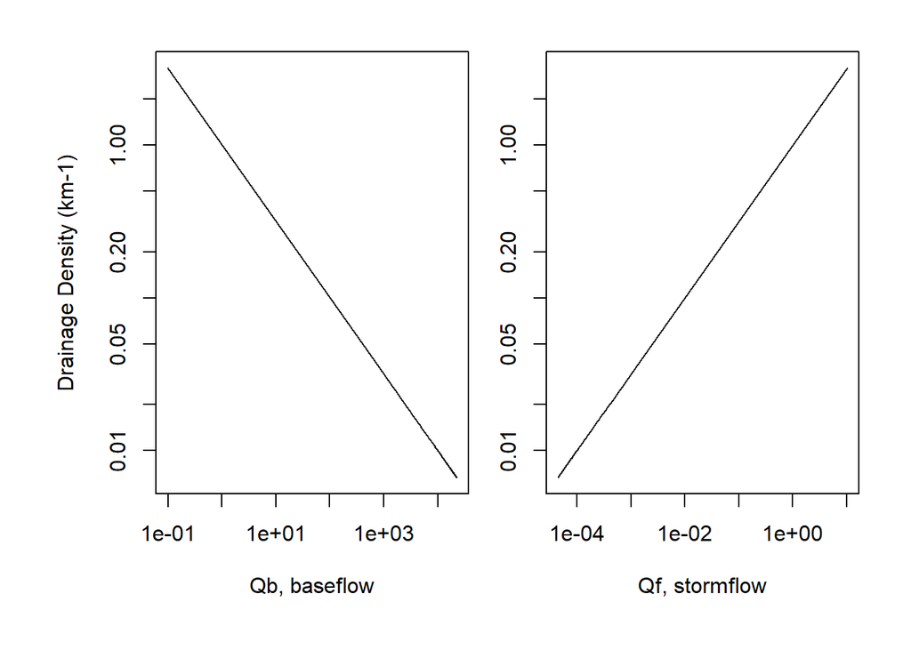

This means that in a watershed with higher drainage density, we would expect not only greater connectivity with the terrestrial ecosystem, but also higher disturbance.

Finally, drainage density scales with other watershed characteristics. Montgomery and Dietrich (1989) determined this equation for drainage density:

$$D = \frac{w_s \rho_w R_0}{W \rho_s K_z
sin \theta cos \theta} \left[ 1 - \frac{tan \theta}{tan \psi}
\right]^{-1}$$
I’ll just define the relevant quantities:
- $R_0$ is average precip, so $D \propto precip$
- $\rho_s$ is the bulk density of the soil, so $D \propto \rho_s^{-1}$
- $K_z$ is the hydraulic conductivity, so $D \propto K_z^{-1}$

This means that drainage density will increase linearly with precipitation, meaning more connectivity with terrestrial ecosystem.

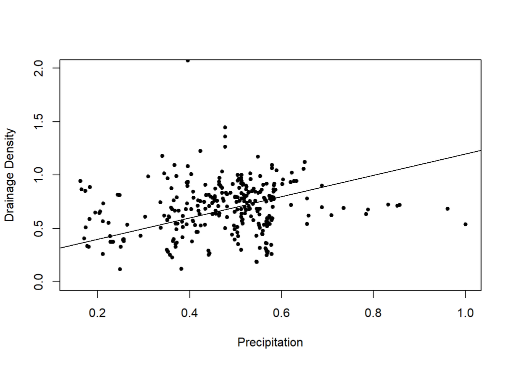